# milestone 1

**CMPS3160 Project: Delays & Declines**

Happy Herold, Syed Mehran

This project is a collaboration between Happy Herold and Syed Mehran for CMPS-3160: Intro to Data Science. The authors intend to investigate how airline operational performance can predict stock prices. To investigate, the authors have compiled data from the last 6 months on airline financials and performance.

**Project Goals:**

> Authors hope to learn about how operational inefficiency contributes to stock prices.

> Authors would also like to learn how soon the market responds to inefficiencies

> Authors want to investigate how one could use this data to develop a model that can predict price shifts due to inefficiency

**Milestone 1:**

To measure airline performance in this project flight data from the Marketing Carrier On-Time Performance table. The flight data contains flight characteristics including date, market carrier, operating carrier, tail number, origin and destination, scheduled departure time, actual departure time, scheduled arrival time, actual arrival time, canceled and diverted flights as well as other key features of the flight. The flight data does not specifically include airline performance metrics. One of the questions that the project aims to answer is if an airline’s flight data can be used to create a metric that can quantify the performance of an airline and can these metrics be used to compare different airlines and be able to predict the stock price. During the ETL process daily number of flights, daily number of cancellations, and proportion of flights that are operated by the market carrier have been calculated using the flight data and plotted.

****Data Set Websites:****

[Marketing Carrier On-Time Performance Data](https://www.transtats.bts.gov/Fields.asp?gnoyr_VQ=FGK)

[Yahoo Finance](https://finance.yahoo.com/)

**Collaboration Plan:**

A private project git repository has been created to store the data and the Colab Jupyter notebook. Authors intend to meet once a week to discuss weekly project goals, raise questions, and develop the final product. Meetings will take place by Zoom or in-person and the pair will communicate using text messaging. The weekly goals and project to-do list are shared in a OneNote document that is shared between the pair. Up until Milestone 2 the authors will continue to calculate various airline performance metrics from the flight data and begin predicting the stock prices based on these metrics with different scikit-learn regression models. After completing Milestone 2, the authors plan on gathering data visualizations and the model to develop a final website and presentation that clearly explains the aim of the project, the steps and tools utilized in the project, and the findings from the analysis and model created.

```python
!git clone https://github.com/syedmehran/cmps3160-project.git
%cd cmps3160-project/
```

```
Cloning into 'cmps3160-project'...
remote: Enumerating objects: 244, done.
remote: Counting objects: 100% (46/46), done.
remote: Compressing objects: 100% (46/46), done.
remote: Total 244 (delta 22), reused 0 (delta 0), pack-reused 198
Receiving objects: 100% (244/244), 254.54 MiB | 5.57 MiB/s, done.
Resolving deltas: 100% (136/136), done.
Updating files: 100% (100/100), done.
/Users/syedmehran/Downloads/cmps3160-project/cmps3160-project
```

```python
import numpy as np
import pandas as pd
import matplotlib.pyplot as plt
import glob
```

```python
#Load stock data in

financ_UAL = pd.read_csv("../finance-data/UAL.csv") # united
financ_ALK = pd.read_csv("../finance-data/ALK.csv") # alaskan
financ_AAL = pd.read_csv("../finance-data/AAL.csv") # american
financ_ALGT = pd.read_csv("../finance-data/ALGT.csv") # allegiant
financ_HA = pd.read_csv("../finance-data/HA.csv") # hawaiian
financ_LUV = pd.read_csv("../finance-data/LUV.csv") # southwest
financ_SAVE = pd.read_csv("../finance-data/SAVE.csv") # spirit
financ_JBLU = pd.read_csv("../finance-data/JBLU.csv") # jetblue
financ_DAL = pd.read_csv("../finance-data/DAL.csv") # delta
financ_JETS = pd.read_csv("../finance-data/JETS.csv") #JETS etf index

financ_airlines = {
    'United': financ_UAL,
    'Alaskan': financ_ALK,
    'American': financ_AAL,
    'Allegiant': financ_ALGT,
    'JetBlue': financ_JBLU,
    'Hawaiian': financ_HA,
    'Southwest': financ_LUV,
    'Spirit': financ_SAVE,
    'Delta': financ_DAL,
    'JETS' : financ_JETS
}

airline_colors = {
    'United': 'blue',
    'Alaskan': 'green',
    'American': 'red',
    'Allegiant': 'cyan',
    'JetBlue': 'magenta',
    'Hawaiian': 'yellow',
    'Southwest': 'black',
    'Spirit': 'orange',
    'Delta': 'purple',
    'JETS': 'brown'
}
```

```python
financ_airline_codes = {'United': 'UAL', 'Alaskan': 'ALK', 'American': 'AAL',
                        'Allegiant': 'ALGT', 'JetBlue': 'JBLU', 'Hawaiian': 'HA',
                        'Southwest': 'LUV', 'Spirit': 'SAVE', 'Delta': 'DAL',
                        'XAL': 'XAL'}

flight_airline_codes = {'American':'AA', 'Delta':'DL', 'Southwest':'WN',
                        'United':'UA', 'Alaskan':'AS', 'Spirit': 'NK',
                        'Hawaiian':'HA', 'Allegiant':'G4', 'JetBlue':'B6',
                        'Frontier':'F9'}
```

Creating airlines dict so we can loop through

```python
financ_JETS.head()
```

|  | Date | Open | High | Low | Close | Adj Close | Volume |
| --- | --- | --- | --- | --- | --- | --- | --- |
| 0 | 2023-01-03 | 17.180000 | 17.330000 | 16.820000 | 16.969999 | 16.969999 | 6249100 |
| 1 | 2023-01-04 | 17.110001 | 17.860001 | 17.110001 | 17.860001 | 17.860001 | 5038900 |
| 2 | 2023-01-05 | 17.750000 | 18.059999 | 17.674999 | 18.059999 | 18.059999 | 3625600 |
| 3 | 2023-01-06 | 18.150000 | 18.450001 | 18.040001 | 18.430000 | 18.430000 | 3203700 |
| 4 | 2023-01-09 | 18.549999 | 18.900000 | 18.540001 | 18.730000 | 18.730000 | 3698700 |

Our most important columns here are date, close, volume and daily return. We will be using date as an index to later correlate cancelations and delays with our daily returns.

```python
for airline, df in financ_airlines.items():
    df['Daily Return'] = df['Close'].pct_change().fillna(0)
```

Now, we want to calculate the daily returns on each store. We can use a for function here to loop through our airlines dictionary from earlier. Since the function produces an NA for 1/03, we will fill that in with 0. We want to investigate daily returns as a percentage change of the previous day, so setting the first day equal to 0 makes sense.

The plot below looks at the daily returns over the 6 months we are investigating. We see they all follow a similar pattern but still exhibit some variation.

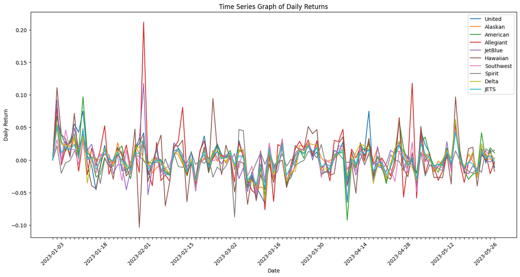

```python
plt.figure(figsize=(14,7))

for airline, df in financ_airlines.items():
    plt.plot(df['Date'], df['Daily Return'], label=airline)

plt.title('Time Series Graph of Daily Returns')
plt.xlabel('Date')
plt.ylabel('Daily Return')
plt.legend()
plt.tight_layout()
plt.xticks(rotation=45)
every_nth = 10
for n, label in enumerate(plt.gca().xaxis.get_ticklabels()):
    if n % every_nth != 0:
        label.set_visible(False)


plt.show()
```

[figure not shown]

```python
plt.figure(figsize=(14,7))

df = financ_airlines['American']

# Plot daily returns on the primary y-axis
ax1 = plt.gca()
ax1.plot(df['Date'], df['Daily Return'], color='b', label='Daily Return')
ax1.set_ylabel('Daily Return', color='b')
ax1.tick_params(axis='y', labelcolor='b')
ax1.set_xlabel('Date')

# Create a secondary y-axis for volume
ax2 = ax1.twinx()
ax2.plot(df['Date'], df['Volume'], color='g', alpha=0.3, label='Volume')
ax2.set_ylabel('Volume', color='g')
ax2.tick_params(axis='y', labelcolor='g')

plt.title('Daily Returns and Volume for United Airlines')
plt.tight_layout()
plt.xticks(rotation=45)
every_nth = 10
for n, label in enumerate(ax1.xaxis.get_ticklabels()):
    if n % every_nth != 0:
        label.set_visible(False)

plt.show()
```

This next plot examines the specific relationships in a scatteprlot between daily return and volume. Based on our previous graph, we may have expected to see some correlation however it seems insignificant.

[figure not shown]

```python
plt.figure(figsize=(14,7))

for airline, df in financ_airlines.items():
    plt.scatter(df['Volume'] / 1e7 , df['Daily Return'], label=airline)  # Divide volume by 1,000,000

m, b = np.polyfit(df['Volume'] / 1e7, df['Daily Return'], 1)

# Plot the line of best fit
plt.plot(df['Volume'] / 1e7, m*(df['Volume'] / 1e7) + b, alpha=0.5)

plt.title('Volume vs. Daily Return')
plt.xlabel('Volume (in hundreds of thousands)')
plt.ylabel('Daily Return')
plt.grid(True)
plt.legend()
plt.show()
```

Trading volume seems to be consistent regardless of levels of daily returns. Line of best fit implies there is a negative correlation between volume and daily returns.

```python
correlations = {}

# Loop through each airline's daily returns
for airline1, df1 in financ_airlines.items():
    for airline2, df2 in financ_airlines.items():
        # Avoid calculating correlation with itself
        if airline1 != airline2:
            key = f"{airline1} vs {airline2}"
            correlation = df1['Daily Return'].corr(df2['Daily Return'])
            correlations[key] = correlation
```

```python
# Create an empty DataFrame for the correlation matrix
correlation_matrix = pd.DataFrame()

# Populate the correlation matrix
for airline1, df1 in financ_airlines.items():
    correlation_matrix[airline1] = [df1['Daily Return'].corr(df2['Daily Return']) for _, df2 in financ_airlines.items()]
```

Creating a correlation matrix so we can examine relationships between shifts in daily returns between all companies.

```python
import seaborn as sns

#create correlation matrix3
cmap = sns.diverging_palette(10, 130, as_cmap=True)
plt.figure(figsize=(10, 8))
sns.heatmap(correlation_matrix, annot=True, cmap = cmap, vmin=-1, vmax=1,
            xticklabels=correlation_matrix.columns,
            yticklabels=correlation_matrix.columns)
plt.title('Correlation Matrix of Daily Returns')
plt.show()
```

[output not shown]

```python
# Load in flight Data
flight_cols = ['MKT_UNIQUE_CARRIER', 'OP_UNIQUE_CARRIER','YEAR', 'QUARTER', 'MONTH', 'DAY_OF_MONTH',
       'DAY_OF_WEEK', 'FL_DATE', 'MKT_CARRIER','OP_CARRIER', 'TAIL_NUM',
        'ORIGIN', 'DEST','CRS_DEP_TIME', 'DEP_TIME', 'DEP_DELAY',
        'DEP_DELAY_NEW', 'DEP_DEL15','DEP_DELAY_GROUP',
        'TAXI_OUT', 'WHEELS_OFF','WHEELS_ON', 'TAXI_IN', 'CRS_ARR_TIME',
        'ARR_TIME', 'ARR_DELAY','ARR_DELAY_NEW', 'ARR_DEL15', 'ARR_DELAY_GROUP',
        'CANCELLED', 'DIVERTED', 'DUP']

airline_code = ['AA', 'DL', 'WN', 'UA', 'AS', 'F9', 'HA', 'G4', 'B6', 'NK']
file_dict = {}
for airline in airline_code:
  file_dict[airline] = glob.glob('../cmps3160-project/2023-*/{}*.csv'.format(airline))
```

Due to upload size restrictions on git the orginal files had to be broken into multiple smaller files. Below the function combines all files with the same market carrier into one DataFrame.

```python
def df_airline(input):
  frame  = pd.read_csv(file_dict[input][0], usecols = flight_cols)
  for file in file_dict[input][1:]:
    frame2 = pd.read_csv(file, usecols = flight_cols)
    frame = pd.concat([frame, frame2], ignore_index=True)
  frame['FL_DATE'] = frame['FL_DATE'].apply(lambda x: x[:-12])
  frame['FL_DATE'] = pd.to_datetime(frame['FL_DATE'])
  return frame
```

```python
df_AA = df_airline('AA') # american
df_DL = df_airline('DL') # delta
df_WN = df_airline('WN') # southwest
df_UA = df_airline('UA') # united
df_AS = df_airline('AS') # alaskan
df_NK = df_airline('NK') # spirit
df_HA = df_airline('HA') # hawaiian
df_G4 = df_airline('G4') # allegiant
df_B6 = df_airline('B6') # jetblue
df_F9 = df_airline('F9') # frontier

flight_airlines = {'AA':df_AA, 'DL':df_DL, 'WN':df_WN,
                        'UA':df_UA, 'AS':df_AS, 'NK': df_NK,
                        'HA':df_HA, 'G4':df_G4, 'B6':df_B6,
                        'F9':df_F9}
```

```python
flight_data = pd.concat([df_AA, df_DL, df_WN, df_UA, df_AS, df_NK, df_HA, df_G4, df_B6, df_F9], axis=0)
```

```python
flight_data.head()
```

[output not shown]

The function delay below calculate the number of delays that the market carrier airline has each day. This can be used to calculate the number of arrival delays or departure delays. The FAA considers a flight that is more that 15 minutes late delay. The columns DEP_DEL15 and ARR_DEL15 are binary with 0 representing not delayed and 1 representing delayed.

```python
# Calculate number of delays using the binary column DEP_DEL15 or ARR_DEL15
def delays(DataFrame, airline, column):
  df = DataFrame.groupby('FL_DATE')[column].sum()
  df.rename('{a}_NUM_{b}'.format(a=airline, b=column), inplace=True)
  return df
```

The following function counts the number of flights an airline as the market carrier flies and the number of cancelations that the airline has in a given day as the market carrier. Two series are created one that counts the number of flights each day and one that counts the number of cancelations each day.

```python
# Calculates the number of flight per day and number of cancelations per day
def num_flights(DataFrame, airline):
  cancelled = DataFrame.groupby('CANCELLED')
  df_FL = cancelled.get_group(0)['FL_DATE'].value_counts()
  df_FL.rename('{}_NUM_FL'.format(airline), inplace=True)

  df_CAN = cancelled.get_group(1)['FL_DATE'].value_counts()
  df_CAN.rename('{}_NUM_CAN'.format(airline), inplace=True)
  return df_FL, df_CAN
```

Using the functions above a DataFrame is created with each market carrier airline series as a column. Each of the functions below has the flight date as the index and the values indicated in the comments for each airline are the columns of the DataFrame.

```python
# Number of Departure Delays
df_DEP_DEL = delays(df_AA, 'AA', 'DEP_DEL15')

# Number of Arrival Delays
df_ARR_DEL = delays(df_AA, 'AA', 'ARR_DEL15')

# Number of Flights
df_NUM_FL = num_flights(df_AA, 'AA')[0]

# Number of Cancelations
df_NUM_CAN = num_flights(df_AA, 'AA')[1]

for airline in airline_code[1:]:
  df_DEP_DEL = pd.concat([df_DEP_DEL, delays(flight_airlines[airline], airline, 'DEP_DEL15')], axis=1)
  df_ARR_DEL = pd.concat([df_ARR_DEL, delays(flight_airlines[airline], airline,'ARR_DEL15')], axis=1)
  df_NUM_FL = pd.concat([df_NUM_FL, num_flights(flight_airlines[airline], airline)[0]], axis=1)
  df_NUM_CAN = pd.concat([df_NUM_CAN, num_flights(flight_airlines[airline], airline)[1]], axis=1)

df_DEP_DEL = df_DEP_DEL.sort_index()
df_ARR_DEL = df_ARR_DEL.sort_index()
df_NUM_FL = df_NUM_FL.sort_index()
df_NUM_CAN = df_NUM_CAN.sort_index()
```

```python
# Plotting Total Daily Depature Delays
fig, ax = plt.subplots(figsize=(14,7))

bottom = np.zeros(len(df_ARR_DEL))
for col in df_DEP_DEL.columns:
  p = ax.bar(df_DEP_DEL.index.strftime('%Y-%m-%d'), df_DEP_DEL[col], label = col[0:2], bottom = bottom)
  bottom += df_DEP_DEL[col]

plt.title('Total Daily Depature Delays')
plt.xlabel('Date')
plt.ylabel('Number of Departure Delays')
ax.set_xticks(ax.get_xticks()[::7])
plt.xticks(rotation=90)
ax.legend(title = 'Market Carrier', loc='upper right')
plt.show()
```

[output not shown]

```python
# Plotting Total Daily Arrival Delays
fig, ax = plt.subplots(figsize=(14,7))

bottom = np.zeros(len(df_ARR_DEL))
for col in df_ARR_DEL.columns:
  p = ax.bar(df_ARR_DEL.index.strftime('%Y-%m-%d'), df_ARR_DEL[col], label = col[0:2], bottom = bottom)
  bottom += df_ARR_DEL[col]

plt.title('Total Arrival Delays')
plt.xlabel('Date')
plt.ylabel('Number of Arrival Delays')
ax.set_xticks(ax.get_xticks()[::7])
plt.xticks(rotation=90)
ax.legend(title = 'Market Carrier', loc='upper right')
plt.show()
```

[output not shown]

```python
# Plotting Market Carrier Daily Depature Delays
fig, ax = plt.subplots(figsize=(14,7))
legend_DEP_DEL = {}
for col in df_DEP_DEL.columns:
  plt.plot(df_DEP_DEL.index.strftime('%Y-%m-%d'), df_DEP_DEL[col])
  legend_DEP_DEL[col[0:2]] = col

plt.title('Market Carrier Daily Depature Delays')
plt.xlabel('Date')
plt.ylabel('Number of Depature Delays')
ax.set_xticks(ax.get_xticks()[::7])
plt.xticks(rotation=90)
ax.legend(legend_DEP_DEL, title = 'Market Carrier', loc='upper right')
plt.show()
```

[output not shown]

```python
#Plotting Market Carrier Daily Number of Flights

fig, ax = plt.subplots(figsize=(14,7))
legend_NUM_FL= {}
for col in df_NUM_FL.columns:
  plt.plot(df_NUM_FL.index.strftime('%Y-%m-%d'), df_NUM_FL[col])
  legend_NUM_FL[col[0:2]] = col

plt.title('Market Carrrier Daily Number of Flights')
plt.xlabel('Date')
plt.ylabel('Number of Flights')
ax.set_xticks(ax.get_xticks()[::7])
plt.xticks(rotation=90)
ax.legend(legend_NUM_FL, title = 'Market Carrier', loc='upper right')
plt.show()
```

[output not shown]

```python
#Plotting Market Carrier Daily Number of Cancelations

fig, ax = plt.subplots(figsize=(14,7))
legend_NUM_CAN= {}
for col in df_NUM_CAN.columns:
  plt.plot(df_NUM_CAN.index.strftime('%Y-%m-%d'), df_NUM_CAN[col])
  legend_NUM_CAN[col[0:2]] = col

plt.title('Market Carrier Daily Number of Canelations')
plt.xlabel('Date')
plt.ylabel('Number of Canelations')
ax.set_xticks(ax.get_xticks()[::7])
plt.xticks(rotation=90)
ax.legend(legend_NUM_CAN, title = 'Market Carrier', loc='upper right')
plt.show()
```

[output not shown]

Since some market carriers use operating carriers to fulfil some of their flights. Looking at the proportion of a market carriers flights that are not operated by the market carrier could help to indicate the market carriers current demands.

```python
def inner_op_mkt(mkt_carrier, airline):
  df = mkt_carrier[airline].to_frame().rename(columns={'FL_DATE':'NUM_SCH_FL'}).reset_index()
  df = df.set_index('FL_DATE')

  op_not_mkt = df[df['OP_UNIQUE_CARRIER']!= airline]
  op_not_mkt = op_not_mkt['NUM_SCH_FL'].rename('OP_NOT_MKT').to_frame().reset_index()
  op_not_mkt = op_not_mkt.groupby('FL_DATE')['OP_NOT_MKT'].sum()

  op_mkt = df[df['OP_UNIQUE_CARRIER'] == airline]
  op_mkt = op_mkt['NUM_SCH_FL'].rename('OP_MKT')

  df_mkt = op_mkt.to_frame().join(op_not_mkt, on='FL_DATE')
  df_mkt['PROP_OP_BY_MKT'] = df_mkt['OP_MKT']/(df_mkt['OP_MKT']+ df_mkt['OP_NOT_MKT'])

  df_mkt = df_mkt.drop(['OP_MKT', 'OP_NOT_MKT'], axis=1)
  return df_mkt
```

```python
# status {0, 1, all}
# Flights = 0
# Canceled = 1
# All Scheduled flights = all
def all_op_mkt(status):
  if status == 0 or  status == 1:
    flights_status = flight_data.groupby('CANCELLED')
    fl_status = flights_status.get_group(status)
  elif status == 'all':
    fl_status = flight_data
  else:
    return None
  airline_code = ['AA', 'DL', 'WN', 'UA', 'AS', 'F9', 'HA', 'G4', 'B6', 'NK']

  mkt_carrier = fl_status.groupby(['MKT_UNIQUE_CARRIER', 'OP_UNIQUE_CARRIER'])['FL_DATE'].value_counts()
  df_op_mkt = inner_op_mkt(mkt_carrier, airline_code[0]).add_suffix('_{}'.format(airline_code[0]))

  for airline in airline_code[1:]:
    df_mkt = inner_op_mkt(mkt_carrier, airline)
    if  df_mkt['PROP_OP_BY_MKT'].isnull().all() == True:
      continue
    else:
      df_mkt = df_mkt.add_suffix('_{}'.format(airline))

    df_op_mkt = df_op_mkt.join(df_mkt, on='FL_DATE')

  df_op_mkt.dropna(how='all', axis=1, inplace=True)
  df_op_mkt.fillna(0, inplace=True)
  df_op_mkt = df_op_mkt.sort_index()

  return df_op_mkt
```

```python
SCH_op_mkt = all_op_mkt('all') # all scheduled flights
FL_op_mkt = all_op_mkt(0) # only flights
CAN_op_mkt = all_op_mkt(1) # only cancelled flight
```

```python
# Proportion of scheduled flight operated by the market carrier
fig, ax = plt.subplots(figsize=(14,7))
l_SCH= {}
for col in SCH_op_mkt.columns:
  plt.plot(SCH_op_mkt.index.strftime('%Y-%m-%d'), SCH_op_mkt[col])
  l_SCH[col[-2:]] = col

plt.title('Proportion of Scheduled Flights Operated by Market Carrier')
plt.xlabel('Date')
plt.ylabel('Proportion of Scheduled Flights')
ax.set_xticks(ax.get_xticks()[::7])
plt.xticks(rotation=90)
ax.legend(l_SCH, title = 'Market Carrier', loc='upper right')
plt.show()
```

[output not shown]

```python
# Proportion of flight operated by the market carrier
fig, ax = plt.subplots(figsize=(14,7))
l_FL= {}
for col in FL_op_mkt.columns:
  plt.plot(FL_op_mkt.index.strftime('%Y-%m-%d'), FL_op_mkt[col])
  l_FL[col[-2:]] = col

plt.title('Proportion of Flights Operated by Market Carrier')
plt.xlabel('Date')
plt.ylabel('Proportion of Flights')
ax.set_xticks(ax.get_xticks()[::7])
plt.xticks(rotation=90)
ax.legend(l_FL, title = 'Market Carrier', loc='upper right')
plt.show()
```

[output not shown]

```python
# Proportion of flight operated by the market carrier
fig, ax = plt.subplots(figsize=(14,7))
l_CAN= {}
for col in FL_op_mkt.columns:
  plt.plot(CAN_op_mkt.index.strftime('%Y-%m-%d'), CAN_op_mkt[col])
  l_CAN[col[-2:]] = col

plt.title('Proportion of Cancellations Operated by Market Carrier')
plt.xlabel('Date')
plt.ylabel('Proportion of Cancellations')
ax.set_xticks(ax.get_xticks()[::7])
plt.xticks(rotation=90)
ax.legend(l_CAN, title = 'Market Carrier', loc='upper right')
plt.show()
```

[output not shown]